# Rancher perceptions of Rx fire in North Dakota

## Contributions to management decisionmaking

Take-aways:

- Respondents mostly value open rangeland
- Respondents have little concern for managing wildfire risk or invasive species
- Respondents are mostly influenced by a sense of stewardship and passed-down knowledge
- Little direct impact of neighbors and science on decisionmaking

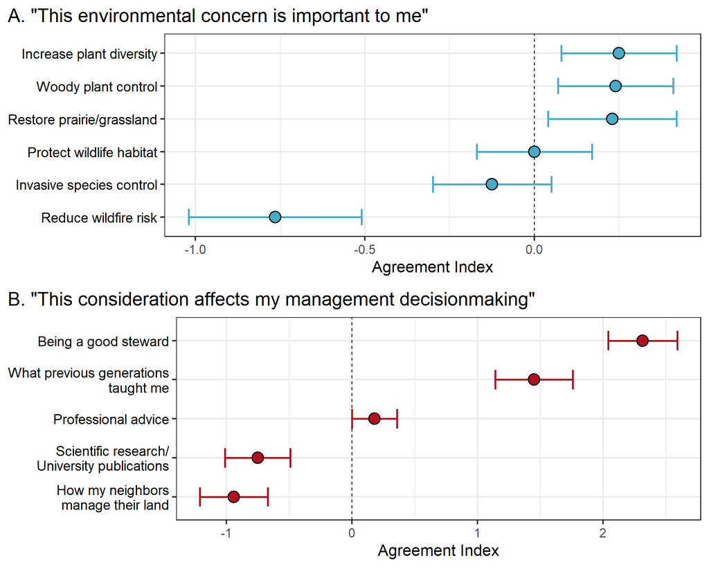

Degree to which respondents agreed that various management considerations (A) were important in their decisions, and (B) influenced their decisionmaking.

```r
importance <-
    responses %>%
      filter(str_starts(QuestionKey, "Importance") ) %>%
      mutate(response = case_when(
              OptionKey == 'restore_prairie' ~      'Restore prairie/grassland',
              OptionKey == 'reduce_wildfire' ~        'Reduce wildfire risk',
              OptionKey == 'protect_wildlife' ~     'Protect wildlife habitat',
              OptionKey == 'heterogeneity' ~   'Increase plant diversity',
              OptionKey == 'control_woody' ~ 'Woody plant control',
              OptionKey == 'control_invasives' ~      'Invasive species control' )) %>%
  ggplot() + theme_bw(16) +
  geom_vline(xintercept = 0, lty = 2) +
  geom_errorbarh(aes(xmin = min,
                     xmax = max,
                     y = fct_reorder(response, mid)),
                 color = wes_palette("FantasticFox1")[3],
                  height = 0.5,
                 lwd = 0.9 ) +
  geom_point(aes(x = mid, y = response ),
             fill = wes_palette("FantasticFox1")[3],
             pch = 21,
             size = 5,
             stroke = 1 ) +
  # coord_cartesian(xlim = c(-1.15, 1.9)) +
  labs(title = 'A. "This environmental concern is important to me"',
       x = 'Agreement Index') +
  theme(axis.title.y = element_blank(),
        axis.text.y = element_text(color = 'black', size = 14),
        plot.title.position = "plot" )
influence <-
    responses %>%
    filter(str_starts(QuestionKey, "Influence") ) %>%
    mutate(response = case_when(
              OptionKey == 'research' ~      'Scientific research/\nUniversity publications',
              OptionKey == 'neighbors' ~     'How my neighbors\nmanage their land',
              OptionKey == 'good' ~          'Being a good steward',
              OptionKey == 'gen' ~   'What previous generations\ntaught me',
              OptionKey == 'advice' ~ 'Professional advice' )) %>%
    ggplot() + theme_bw(16) +
    geom_vline(xintercept = 0, lty = 2) +
    geom_errorbarh(aes(xmin = min,
                       xmax = max,
                       y = fct_reorder(response, mid)),
                   color = wes_palette("FantasticFox1")[5],
                   height = 0.5,
                   lwd = 0.9 ) +
    geom_point(aes(x = mid, y = response ),
               fill = wes_palette("FantasticFox1")[5],
               pch = 21,
               size = 5,
               stroke = 1 ) +
    # coord_cartesian(xlim = c(-1.15, 1.9)) +
    labs(title = 'B. "This consideration affects my management decisionmaking"',
         x = 'Agreement Index') +
    theme(axis.title.y = element_blank(),
          axis.text.y = element_text(color = 'black', size = 14),
          plot.title.position = "plot" )
plot_grid(importance,
          influence,
           # labels = c('A', 'B'),
          ncol = 1)
```

## Attitudes about fire

Take-aways

- Respondents generally believe their community has negative perceptions of Rx fire, except for wildlife
- Respondents have a conservative attitude towards Rx fire use and show a disinclination to use it themselves

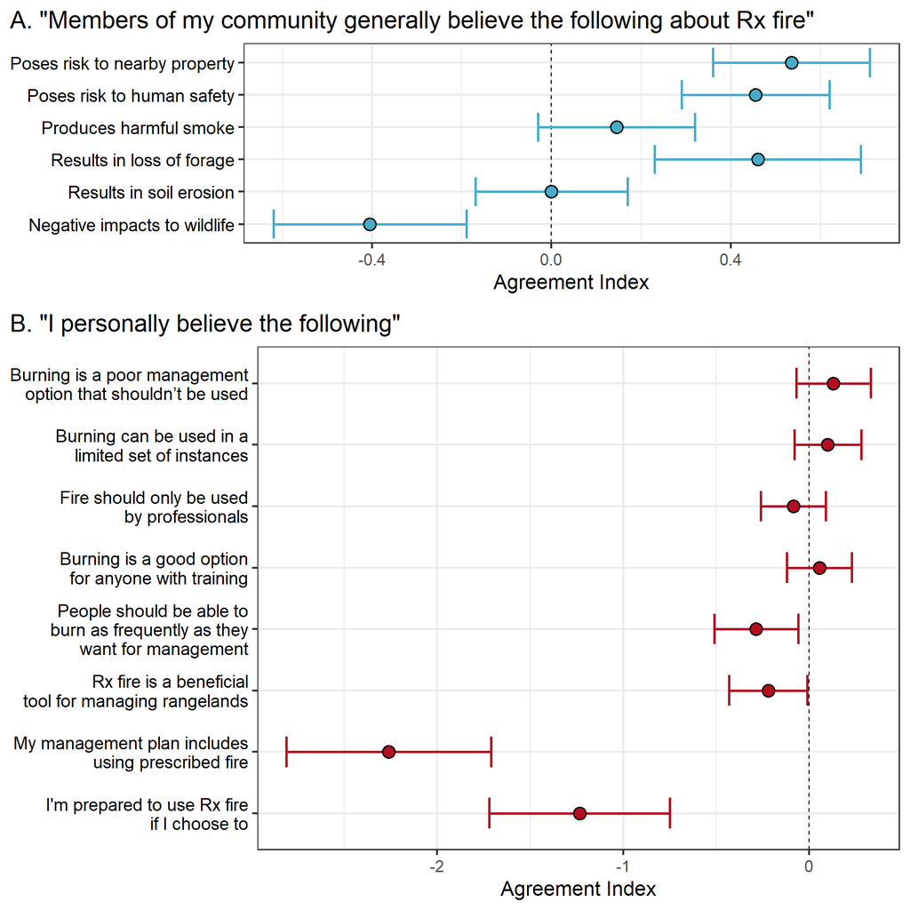

Degree to which respondents agreed with statements about (A) community perceptions of prescribed fire effects, and (B) personal attitudes about prescribed fire use.

```r
# Attitudes and beliefs about Rx fire
beliefs <-
  responses %>%
    filter(QuestionKey == "CommunityFireBeliefs")  %>%
    mutate(OptionKey = str_remove(OptionKey, 'burn_'),
           response = case_when(
              OptionKey == 'wildlife' ~ 'Negative impacts to wildlife',
              OptionKey == 'soil_erosion' ~   'Results in soil erosion',
              OptionKey == 'smoke' ~    'Produces harmful smoke',
              OptionKey == 'safety' ~   'Poses risk to human safety',
              OptionKey == 'property_risk' ~   "Poses risk to nearby property",
              OptionKey == 'forage' ~      'Results in loss of forage' )) %>%
    ggplot() + theme_bw(16) +
    geom_vline(xintercept = 0, lty = 2) +
    geom_errorbarh(aes(xmin = min,
                       xmax = max,
                       y = fct_reorder(response, desc(SurveyOrder))) ,
                   color = wes_palette("FantasticFox1")[3],
                   lwd = 0.9 ) +
    geom_point(aes(x = mid, y = response ),
               fill = wes_palette("FantasticFox1")[3],
               pch = 21,
               size = 4,
               stroke = 1 ) +
    # coord_cartesian(xlim = c(-1.15, 1.9)) +
    labs(title = 'A. "Members of my community generally believe the following about Rx fire"',
         x = 'Agreement Index') +
    theme(axis.title.y = element_blank(),
          axis.text.y = element_text(color = 'black', size = 14),
          plot.title.position = "plot" )
attitudes <-
  responses %>%
    filter(str_starts(QuestionKey, "Attitudes") ) %>%
    mutate(OptionKey = str_remove(OptionKey, 'burn_'),
           response = case_when(
             OptionKey == 'beneficial' ~ 'Rx fire is a beneficial\ntool for managing rangelands',
             OptionKey == 'frequent' ~   'People should be able to\nburn as frequently as they\n want for management',
             OptionKey == 'limited' ~    'Burning can be used in a\nlimited set of instances',
             OptionKey == 'man_plan' ~   'My management plan includes\nusing prescribed fire',
             OptionKey == 'prepared' ~   "I'm prepared to use Rx fire\nif I choose to",
             OptionKey == 'pros' ~      'Fire should only be used\nby professionals',
             OptionKey == 'shouldnt' ~   'Burning is a poor management\noption that shouldn’t be used',
             OptionKey == 'training' ~ 'Burning is a good option\nfor anyone with training')) %>%
    ggplot() + theme_bw(16) +
    geom_vline(xintercept = 0, lty = 2) +
    geom_errorbarh(aes(xmin = min,
                       xmax = max,
                       y = fct_reorder(response, desc(SurveyOrder))) ,
                   height = 0.5,
                   color = wes_palette("FantasticFox1")[5],
                   lwd = 0.9 ) +
    geom_point(aes(x = mid, y = response ),
               fill = wes_palette("FantasticFox1")[5],
               pch = 21,
               size = 4,
               stroke = 1 ) +
    # coord_cartesian(xlim = c(-1.15, 1.9)) +
    labs(title = 'B. "I personally believe the following"',
         x = 'Agreement Index') +
    theme(axis.title.y = element_blank(),
          axis.text.y = element_text(color = 'black', size = 14),
          plot.title.position = "plot" )
plot_grid(beliefs,
          attitudes,
          rel_heights = c(0.75, 1.5),
          ncol = 1)
```

## Public grazing land management and personal recreation

Take-aways

- Respondents expect administrators to use good science
- Respondents do not want to see Rx fire expanded on public grazingland
- Respondents really don’t use public grazlinglands for recreation

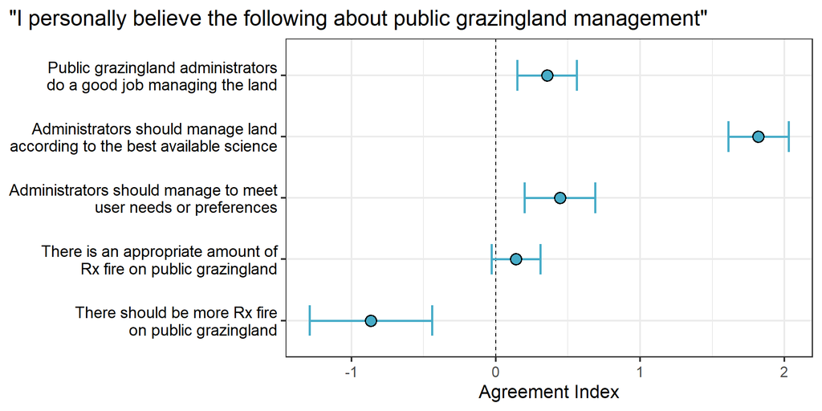

Respondent attitudes towards public grazingland administration and prescribed fire use.

```r
responses %>%
  filter(QuestionKey == "PublicGrazingBeliefs",
         OptionKey != 'public_fire')  %>%
  mutate(response = case_when(
           OptionKey == 'increase_public_fire' ~ 'There should be more Rx fire\non public grazingland',            OptionKey == 'amount_public_fire' ~'There is an appropriate amount of\nRx fire on public grazingland',
           OptionKey == 'admin_users' ~ 'Administrators should manage to meet\nuser needs or preferences',
           OptionKey == 'admin_science' ~ "Administrators should manage land\naccording to the best available science",
           OptionKey == 'admin_good' ~ 'Public grazingland administrators\n do a good job managing the land' )) %>%
  ggplot() + theme_bw(16) +
  geom_vline(xintercept = 0, lty = 2) +
  geom_errorbarh(aes(xmin = min,
                     xmax = max,
                     y = fct_reorder(response, desc(SurveyOrder))) ,
                 color = wes_palette("FantasticFox1")[3],
                 height = 0.5,
                 lwd = 0.9 ) +
  geom_point(aes(x = mid, y = response ),
             fill = wes_palette("FantasticFox1")[3],
             pch = 21,
             size = 4,
             stroke = 1 ) +
  # coord_cartesian(xlim = c(-1.15, 1.9)) +
  labs(title = '"I personally believe the following about public grazingland management"',
       x = 'Agreement Index') +
  theme(axis.title.y = element_blank(),
        axis.text.y = element_text(color = 'black', size = 14),
        plot.title.position = "plot" )
```

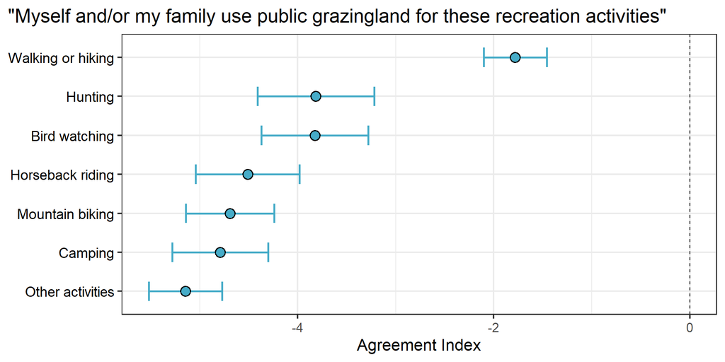

Respondents’ use of public grazingland for various recreation activies.

```r
responses %>%
  filter(QuestionKey == 'Recreation' ) %>%
  ggplot() + theme_bw(16) +
  geom_vline(xintercept = 0, lty = 2) +
  geom_errorbarh(aes(xmin = min,
                     xmax = max,
                     y = fct_reorder(SurveyText, mid) ) ,
                 color = wes_palette("FantasticFox1")[3],
                 height = 0.5,
                 lwd = 0.9 ) +
  geom_point(aes(x = mid, y = SurveyText ),
             fill = wes_palette("FantasticFox1")[3],
             pch = 21,
             size = 4,
             stroke = 1 ) +
  # coord_cartesian(xlim = c(-1.15, 1.9)) +
  labs(title = '"Myself and/or my family use public grazingland for these recreation activities"',
       x = 'Agreement Index') +
  theme(axis.title.y = element_blank(),
        axis.text.y = element_text(color = 'black', size = 14),
        plot.title.position = "plot" )
```